# Risk Factor Analysis

## Outcome Variable

**Outcome Variable:** ever_stunted

## Predictor Variables

**Intervention Variable:** mage

**Adjustment Set:**

- arm
- meducyrs
- feducyrs
- W_mhtcm
- single
- delta_meducyrs
- delta_feducyrs
- delta_W_mhtcm
- delta_single

## Stratifying Variables

The analysis was stratified on these variable(s):

- agecat
- studyid
- country

## Data Summary

| agecat | studyid | country | mage | ever_stunted | n_cell | n |
| --- | --- | --- | --- | --- | --- | --- |
| 0-24 months | ki0047075b-MAL-ED | BANGLADESH | [20-30) | 0 | 78 | 265 |
| 0-24 months | ki0047075b-MAL-ED | BANGLADESH | [20-30) | 1 | 104 | 265 |
| 0-24 months | ki0047075b-MAL-ED | BANGLADESH | <20 | 0 | 8 | 265 |
| 0-24 months | ki0047075b-MAL-ED | BANGLADESH | <20 | 1 | 29 | 265 |
| 0-24 months | ki0047075b-MAL-ED | BANGLADESH | >=30 | 0 | 18 | 265 |
| 0-24 months | ki0047075b-MAL-ED | BANGLADESH | >=30 | 1 | 28 | 265 |
| 0-24 months | ki0047075b-MAL-ED | BRAZIL | [20-30) | 0 | 103 | 233 |
| 0-24 months | ki0047075b-MAL-ED | BRAZIL | [20-30) | 1 | 36 | 233 |
| 0-24 months | ki0047075b-MAL-ED | BRAZIL | <20 | 0 | 34 | 233 |
| 0-24 months | ki0047075b-MAL-ED | BRAZIL | <20 | 1 | 9 | 233 |
| 0-24 months | ki0047075b-MAL-ED | BRAZIL | >=30 | 0 | 42 | 233 |
| 0-24 months | ki0047075b-MAL-ED | BRAZIL | >=30 | 1 | 9 | 233 |
| 0-24 months | ki0047075b-MAL-ED | INDIA | [20-30) | 0 | 75 | 249 |
| 0-24 months | ki0047075b-MAL-ED | INDIA | [20-30) | 1 | 119 | 249 |
| 0-24 months | ki0047075b-MAL-ED | INDIA | <20 | 0 | 15 | 249 |
| 0-24 months | ki0047075b-MAL-ED | INDIA | <20 | 1 | 19 | 249 |
| 0-24 months | ki0047075b-MAL-ED | INDIA | >=30 | 0 | 11 | 249 |
| 0-24 months | ki0047075b-MAL-ED | INDIA | >=30 | 1 | 10 | 249 |
| 0-24 months | ki0047075b-MAL-ED | NEPAL | [20-30) | 0 | 127 | 240 |
| 0-24 months | ki0047075b-MAL-ED | NEPAL | [20-30) | 1 | 62 | 240 |
| 0-24 months | ki0047075b-MAL-ED | NEPAL | <20 | 0 | 2 | 240 |
| 0-24 months | ki0047075b-MAL-ED | NEPAL | <20 | 1 | 3 | 240 |
| 0-24 months | ki0047075b-MAL-ED | NEPAL | >=30 | 0 | 28 | 240 |
| 0-24 months | ki0047075b-MAL-ED | NEPAL | >=30 | 1 | 18 | 240 |
| 0-24 months | ki0047075b-MAL-ED | PERU | [20-30) | 0 | 61 | 303 |
| 0-24 months | ki0047075b-MAL-ED | PERU | [20-30) | 1 | 92 | 303 |
| 0-24 months | ki0047075b-MAL-ED | PERU | <20 | 0 | 29 | 303 |
| 0-24 months | ki0047075b-MAL-ED | PERU | <20 | 1 | 54 | 303 |
| 0-24 months | ki0047075b-MAL-ED | PERU | >=30 | 0 | 25 | 303 |
| 0-24 months | ki0047075b-MAL-ED | PERU | >=30 | 1 | 42 | 303 |

[output cut: 450 more lines]

The following strata were considered:

- agecat: 0-24 months, studyid: ki0047075b-MAL-ED, country: BANGLADESH
- agecat: 0-24 months, studyid: ki0047075b-MAL-ED, country: BRAZIL
- agecat: 0-24 months, studyid: ki0047075b-MAL-ED, country: INDIA
- agecat: 0-24 months, studyid: ki0047075b-MAL-ED, country: NEPAL
- agecat: 0-24 months, studyid: ki0047075b-MAL-ED, country: PERU
- agecat: 0-24 months, studyid: ki0047075b-MAL-ED, country: SOUTH AFRICA
- agecat: 0-24 months, studyid: ki0047075b-MAL-ED, country: TANZANIA, UNITED REPUBLIC OF
- agecat: 0-24 months, studyid: ki1000108-CMC-V-BCS-2002, country: INDIA
- agecat: 0-24 months, studyid: ki1000108-IRC, country: INDIA
- agecat: 0-24 months, studyid: ki1000109-EE, country: PAKISTAN
- agecat: 0-24 months, studyid: ki1000304b-SAS-CompFeed, country: INDIA
- agecat: 0-24 months, studyid: ki1000304b-SAS-FoodSuppl, country: INDIA
- agecat: 0-24 months, studyid: ki1017093-NIH-Birth, country: BANGLADESH
- agecat: 0-24 months, studyid: ki1017093b-PROVIDE, country: BANGLADESH
- agecat: 0-24 months, studyid: ki1017093c-NIH-Crypto, country: BANGLADESH
- agecat: 0-24 months, studyid: ki1066203-TanzaniaChild2, country: TANZANIA, UNITED REPUBLIC OF
- agecat: 0-24 months, studyid: ki1101329-Keneba, country: GAMBIA
- agecat: 0-24 months, studyid: ki1112895-Guatemala BSC, country: GUATEMALA
- agecat: 0-24 months, studyid: ki1112895-iLiNS-Zinc, country: BURKINA FASO
- agecat: 0-24 months, studyid: ki1113344-GMS-Nepal, country: NEPAL
- agecat: 0-24 months, studyid: ki1119695-PROBIT, country: BELARUS
- agecat: 0-24 months, studyid: ki1126311-ZVITAMBO, country: ZIMBABWE
- agecat: 0-24 months, studyid: ki1135781-COHORTS, country: GUATEMALA
- agecat: 0-24 months, studyid: ki1135781-COHORTS, country: INDIA
- agecat: 0-24 months, studyid: ki1135781-COHORTS, country: PHILIPPINES
- agecat: 0-24 months, studyid: ki1148112-LCNI-5, country: MALAWI
- agecat: 0-24 months, studyid: kiGH5241-JiVitA-3, country: BANGLADESH
- agecat: 0-6 months, studyid: ki0047075b-MAL-ED, country: BANGLADESH
- agecat: 0-6 months, studyid: ki0047075b-MAL-ED, country: BRAZIL
- agecat: 0-6 months, studyid: ki0047075b-MAL-ED, country: INDIA
- agecat: 0-6 months, studyid: ki0047075b-MAL-ED, country: NEPAL
- agecat: 0-6 months, studyid: ki0047075b-MAL-ED, country: PERU
- agecat: 0-6 months, studyid: ki0047075b-MAL-ED, country: SOUTH AFRICA
- agecat: 0-6 months, studyid: ki0047075b-MAL-ED, country: TANZANIA, UNITED REPUBLIC OF
- agecat: 0-6 months, studyid: ki1000108-CMC-V-BCS-2002, country: INDIA
- agecat: 0-6 months, studyid: ki1000108-IRC, country: INDIA
- agecat: 0-6 months, studyid: ki1000109-EE, country: PAKISTAN
- agecat: 0-6 months, studyid: ki1000304b-SAS-CompFeed, country: INDIA
- agecat: 0-6 months, studyid: ki1000304b-SAS-FoodSuppl, country: INDIA
- agecat: 0-6 months, studyid: ki1017093-NIH-Birth, country: BANGLADESH
- agecat: 0-6 months, studyid: ki1017093b-PROVIDE, country: BANGLADESH
- agecat: 0-6 months, studyid: ki1017093c-NIH-Crypto, country: BANGLADESH
- agecat: 0-6 months, studyid: ki1066203-TanzaniaChild2, country: TANZANIA, UNITED REPUBLIC OF
- agecat: 0-6 months, studyid: ki1101329-Keneba, country: GAMBIA
- agecat: 0-6 months, studyid: ki1112895-Guatemala BSC, country: GUATEMALA
- agecat: 0-6 months, studyid: ki1113344-GMS-Nepal, country: NEPAL
- agecat: 0-6 months, studyid: ki1119695-PROBIT, country: BELARUS
- agecat: 0-6 months, studyid: ki1126311-ZVITAMBO, country: ZIMBABWE
- agecat: 0-6 months, studyid: ki1135781-COHORTS, country: GUATEMALA
- agecat: 0-6 months, studyid: ki1135781-COHORTS, country: INDIA
- agecat: 0-6 months, studyid: ki1135781-COHORTS, country: PHILIPPINES
- agecat: 0-6 months, studyid: ki1148112-LCNI-5, country: MALAWI
- agecat: 0-6 months, studyid: kiGH5241-JiVitA-3, country: BANGLADESH
- agecat: 6-24 months, studyid: ki0047075b-MAL-ED, country: BANGLADESH
- agecat: 6-24 months, studyid: ki0047075b-MAL-ED, country: BRAZIL
- agecat: 6-24 months, studyid: ki0047075b-MAL-ED, country: INDIA
- agecat: 6-24 months, studyid: ki0047075b-MAL-ED, country: NEPAL
- agecat: 6-24 months, studyid: ki0047075b-MAL-ED, country: PERU
- agecat: 6-24 months, studyid: ki0047075b-MAL-ED, country: SOUTH AFRICA
- agecat: 6-24 months, studyid: ki0047075b-MAL-ED, country: TANZANIA, UNITED REPUBLIC OF
- agecat: 6-24 months, studyid: ki1000108-CMC-V-BCS-2002, country: INDIA
- agecat: 6-24 months, studyid: ki1000108-IRC, country: INDIA
- agecat: 6-24 months, studyid: ki1000109-EE, country: PAKISTAN
- agecat: 6-24 months, studyid: ki1000304b-SAS-CompFeed, country: INDIA
- agecat: 6-24 months, studyid: ki1000304b-SAS-FoodSuppl, country: INDIA
- agecat: 6-24 months, studyid: ki1017093-NIH-Birth, country: BANGLADESH
- agecat: 6-24 months, studyid: ki1017093b-PROVIDE, country: BANGLADESH
- agecat: 6-24 months, studyid: ki1017093c-NIH-Crypto, country: BANGLADESH
- agecat: 6-24 months, studyid: ki1066203-TanzaniaChild2, country: TANZANIA, UNITED REPUBLIC OF
- agecat: 6-24 months, studyid: ki1101329-Keneba, country: GAMBIA
- agecat: 6-24 months, studyid: ki1112895-Guatemala BSC, country: GUATEMALA
- agecat: 6-24 months, studyid: ki1112895-iLiNS-Zinc, country: BURKINA FASO
- agecat: 6-24 months, studyid: ki1113344-GMS-Nepal, country: NEPAL
- agecat: 6-24 months, studyid: ki1119695-PROBIT, country: BELARUS
- agecat: 6-24 months, studyid: ki1126311-ZVITAMBO, country: ZIMBABWE
- agecat: 6-24 months, studyid: ki1135781-COHORTS, country: GUATEMALA
- agecat: 6-24 months, studyid: ki1135781-COHORTS, country: INDIA
- agecat: 6-24 months, studyid: ki1135781-COHORTS, country: PHILIPPINES
- agecat: 6-24 months, studyid: ki1148112-LCNI-5, country: MALAWI
- agecat: 6-24 months, studyid: kiGH5241-JiVitA-3, country: BANGLADESH

### Dropped Strata

Some strata were dropped due to rare outcomes:

- agecat: 0-24 months, studyid: ki0047075b-MAL-ED, country: NEPAL
- agecat: 0-24 months, studyid: ki0047075b-MAL-ED, country: TANZANIA, UNITED REPUBLIC OF
- agecat: 0-24 months, studyid: ki1000108-CMC-V-BCS-2002, country: INDIA
- agecat: 0-24 months, studyid: ki1000109-EE, country: PAKISTAN
- agecat: 0-6 months, studyid: ki0047075b-MAL-ED, country: INDIA
- agecat: 0-6 months, studyid: ki0047075b-MAL-ED, country: NEPAL
- agecat: 0-6 months, studyid: ki0047075b-MAL-ED, country: TANZANIA, UNITED REPUBLIC OF
- agecat: 0-6 months, studyid: ki1000109-EE, country: PAKISTAN
- agecat: 6-24 months, studyid: ki0047075b-MAL-ED, country: BRAZIL
- agecat: 6-24 months, studyid: ki0047075b-MAL-ED, country: NEPAL
- agecat: 6-24 months, studyid: ki0047075b-MAL-ED, country: TANZANIA, UNITED REPUBLIC OF
- agecat: 6-24 months, studyid: ki1000108-CMC-V-BCS-2002, country: INDIA
- agecat: 6-24 months, studyid: ki1000108-IRC, country: INDIA
- agecat: 6-24 months, studyid: ki1000109-EE, country: PAKISTAN

## Methods Detail

We’re interested in the causal parameters $E[Y_a]$ for all values of $a \in \mathcal{A}$. These parameters represent the mean outcome if, possibly contrary to fact, we intervened to set all units to have $A=a$. Under the randomization and positivity assumptions, these are identified by the statistical parameters $\psi_a=E_W[E_{Y|A,W}(Y|A=a,W)]$. In addition, we’re interested in the mean of $Y$, $E[Y]$ under no intervention (the observed mean). We will estimate these parameters by using SuperLearner to fit the relevant likelihood factors – $E_{Y|A,W}(Y|A=a,W)$ and $p(A=a|W)$, and then updating our likelihood fit using a joint TMLE.

For unadjusted analyses ($W=\{\}$), initial likelihoods were estimated using Lrnr_glm to estimate the simple $E(Y|A)$ and Lrnr_mean to estimate $p(A)$. For adjusted analyses, a small library containing Lrnr_glmnet, Lrnr_xgboost, and Lrnr_mean was used.

Having estimated these parameters, we will then use the delta method to estimate relative risks and attributable risks relative to a prespecified baseline level of $A$.

# Results Detail

## Results Plots

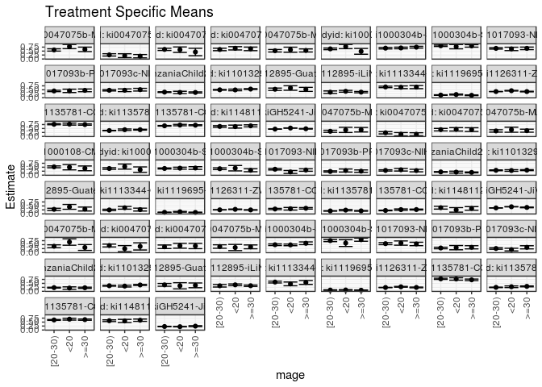

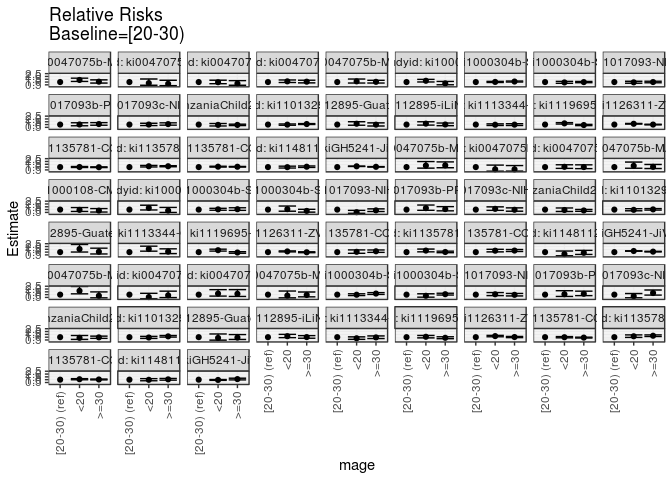

[figure not shown]

[figure not shown]

## Results Table

### Parameter: TSM

| agecat | studyid | country | intervention_level | baseline_level | estimate | ci_lower | ci_upper |
| --- | --- | --- | --- | --- | --- | --- | --- |
| 0-24 months | ki0047075b-MAL-ED | BANGLADESH | [20-30) | NA | 0.5714286 | 0.4993965 | 0.6434607 |
| 0-24 months | ki0047075b-MAL-ED | BANGLADESH | <20 | NA | 0.7837838 | 0.6508882 | 0.9166793 |
| 0-24 months | ki0047075b-MAL-ED | BANGLADESH | >=30 | NA | 0.6086957 | 0.4673939 | 0.7499974 |
| 0-24 months | ki0047075b-MAL-ED | BRAZIL | [20-30) | NA | 0.2589928 | 0.1860085 | 0.3319772 |
| 0-24 months | ki0047075b-MAL-ED | BRAZIL | <20 | NA | 0.2093023 | 0.0874482 | 0.3311564 |
| 0-24 months | ki0047075b-MAL-ED | BRAZIL | >=30 | NA | 0.1764706 | 0.0716196 | 0.2813216 |
| 0-24 months | ki0047075b-MAL-ED | INDIA | [20-30) | NA | 0.6065933 | 0.5383758 | 0.6748109 |
| 0-24 months | ki0047075b-MAL-ED | INDIA | <20 | NA | 0.5870828 | 0.4126768 | 0.7614889 |
| 0-24 months | ki0047075b-MAL-ED | INDIA | >=30 | NA | 0.4415821 | 0.2077896 | 0.6753747 |
| 0-24 months | ki0047075b-MAL-ED | PERU | [20-30) | NA | 0.6017380 | 0.5241304 | 0.6793455 |
| 0-24 months | ki0047075b-MAL-ED | PERU | <20 | NA | 0.6750840 | 0.5715605 | 0.7786074 |
| 0-24 months | ki0047075b-MAL-ED | PERU | >=30 | NA | 0.6390453 | 0.5258870 | 0.7522036 |
| 0-24 months | ki0047075b-MAL-ED | SOUTH AFRICA | [20-30) | NA | 0.5211351 | 0.4417748 | 0.6004954 |
| 0-24 months | ki0047075b-MAL-ED | SOUTH AFRICA | <20 | NA | 0.5860401 | 0.4262460 | 0.7458342 |
| 0-24 months | ki0047075b-MAL-ED | SOUTH AFRICA | >=30 | NA | 0.5396741 | 0.4422618 | 0.6370863 |
| 0-24 months | ki1000108-IRC | INDIA | [20-30) | NA | 0.6395349 | 0.5887350 | 0.6903348 |
| 0-24 months | ki1000108-IRC | INDIA | <20 | NA | 0.7837838 | 0.6509771 | 0.9165904 |
| 0-24 months | ki1000108-IRC | INDIA | >=30 | NA | 0.4827586 | 0.3006666 | 0.6648507 |
| 0-24 months | ki1000304b-SAS-CompFeed | INDIA | [20-30) | NA | 0.6845978 | 0.6362412 | 0.7329544 |
| 0-24 months | ki1000304b-SAS-CompFeed | INDIA | <20 | NA | 0.6977515 | 0.6472124 | 0.7482906 |
| 0-24 months | ki1000304b-SAS-CompFeed | INDIA | >=30 | NA | 0.7454070 | 0.6891587 | 0.8016552 |
| 0-24 months | ki1000304b-SAS-FoodSuppl | INDIA | [20-30) | NA | 0.8344828 | 0.7916575 | 0.8773080 |
| 0-24 months | ki1000304b-SAS-FoodSuppl | INDIA | <20 | NA | 0.7777778 | 0.6418092 | 0.9137463 |
| 0-24 months | ki1000304b-SAS-FoodSuppl | INDIA | >=30 | NA | 0.8260870 | 0.7485421 | 0.9036319 |
| 0-24 months | ki1017093-NIH-Birth | BANGLADESH | [20-30) | NA | 0.6709941 | 0.6264326 | 0.7155556 |
| 0-24 months | ki1017093-NIH-Birth | BANGLADESH | <20 | NA | 0.6374727 | 0.5304775 | 0.7444680 |
| 0-24 months | ki1017093-NIH-Birth | BANGLADESH | >=30 | NA | 0.6708399 | 0.5902880 | 0.7513919 |
| 0-24 months | ki1017093b-PROVIDE | BANGLADESH | [20-30) | NA | 0.4266856 | 0.3833651 | 0.4700062 |
| 0-24 months | ki1017093b-PROVIDE | BANGLADESH | <20 | NA | 0.4336732 | 0.3280260 | 0.5393204 |
| 0-24 months | ki1017093b-PROVIDE | BANGLADESH | >=30 | NA | 0.4637218 | 0.3771880 | 0.5502555 |

[output cut: 168 more lines]

### Parameter: E(Y)

| agecat | studyid | country | intervention_level | baseline_level | estimate | ci_lower | ci_upper |
| --- | --- | --- | --- | --- | --- | --- | --- |
| 0-24 months | ki0047075b-MAL-ED | BANGLADESH | NA | NA | 0.6075472 | 0.5486452 | 0.6664491 |
| 0-24 months | ki0047075b-MAL-ED | BRAZIL | NA | NA | 0.2317597 | 0.1774632 | 0.2860561 |
| 0-24 months | ki0047075b-MAL-ED | INDIA | NA | NA | 0.5943775 | 0.5332672 | 0.6554878 |
| 0-24 months | ki0047075b-MAL-ED | PERU | NA | NA | 0.6204620 | 0.5657315 | 0.6751926 |
| 0-24 months | ki0047075b-MAL-ED | SOUTH AFRICA | NA | NA | 0.5445860 | 0.4894148 | 0.5997572 |
| 0-24 months | ki1000108-IRC | INDIA | NA | NA | 0.6414634 | 0.5949863 | 0.6879405 |
| 0-24 months | ki1000304b-SAS-CompFeed | INDIA | NA | NA | 0.6914547 | 0.6510509 | 0.7318584 |
| 0-24 months | ki1000304b-SAS-FoodSuppl | INDIA | NA | NA | 0.8277512 | 0.7915095 | 0.8639929 |
| 0-24 months | ki1017093-NIH-Birth | BANGLADESH | NA | NA | 0.6634769 | 0.6264616 | 0.7004922 |
| 0-24 months | ki1017093b-PROVIDE | BANGLADESH | NA | NA | 0.4342857 | 0.3975409 | 0.4710305 |
| 0-24 months | ki1017093c-NIH-Crypto | BANGLADESH | NA | NA | 0.4775726 | 0.4419904 | 0.5131548 |
| 0-24 months | ki1066203-TanzaniaChild2 | TANZANIA, UNITED REPUBLIC OF | NA | NA | 0.3459596 | 0.3268289 | 0.3650903 |
| 0-24 months | ki1101329-Keneba | GAMBIA | NA | NA | 0.5183631 | 0.5000444 | 0.5366817 |
| 0-24 months | ki1112895-Guatemala BSC | GUATEMALA | NA | NA | 0.5551601 | 0.4969525 | 0.6133678 |
| 0-24 months | ki1112895-iLiNS-Zinc | BURKINA FASO | NA | NA | 0.3559962 | 0.3060347 | 0.4059578 |
| 0-24 months | ki1113344-GMS-Nepal | NEPAL | NA | NA | 0.6744186 | 0.6369554 | 0.7118819 |
| 0-24 months | ki1119695-PROBIT | BELARUS | NA | NA | 0.1674854 | 0.1488048 | 0.1861659 |
| 0-24 months | ki1126311-ZVITAMBO | ZIMBABWE | NA | NA | 0.3966365 | 0.3885423 | 0.4047307 |
| 0-24 months | ki1135781-COHORTS | GUATEMALA | NA | NA | 0.7639706 | 0.7413939 | 0.7865473 |
| 0-24 months | ki1135781-COHORTS | INDIA | NA | NA | 0.3877282 | 0.3746257 | 0.4008307 |
| 0-24 months | ki1135781-COHORTS | PHILIPPINES | NA | NA | 0.6863963 | 0.6699497 | 0.7028430 |
| 0-24 months | ki1148112-LCNI-5 | MALAWI | NA | NA | 0.6373134 | 0.6008819 | 0.6737450 |
| 0-24 months | kiGH5241-JiVitA-3 | BANGLADESH | NA | NA | 0.4937741 | 0.4859396 | 0.5016087 |
| 0-6 months | ki0047075b-MAL-ED | BANGLADESH | NA | NA | 0.3547170 | 0.2970055 | 0.4124285 |
| 0-6 months | ki0047075b-MAL-ED | BRAZIL | NA | NA | 0.1931330 | 0.1423366 | 0.2439295 |
| 0-6 months | ki0047075b-MAL-ED | PERU | NA | NA | 0.4257426 | 0.3699763 | 0.4815088 |
| 0-6 months | ki0047075b-MAL-ED | SOUTH AFRICA | NA | NA | 0.3598726 | 0.3067005 | 0.4130447 |
| 0-6 months | ki1000108-CMC-V-BCS-2002 | INDIA | NA | NA | 0.5108696 | 0.4597270 | 0.5620121 |
| 0-6 months | ki1000108-IRC | INDIA | NA | NA | 0.4243902 | 0.3764905 | 0.4722900 |
| 0-6 months | ki1000304b-SAS-CompFeed | INDIA | NA | NA | 0.4254902 | 0.3977202 | 0.4532601 |
| 0-6 months | ki1000304b-SAS-FoodSuppl | INDIA | NA | NA | 0.3894231 | 0.3425088 | 0.4363374 |
| 0-6 months | ki1017093-NIH-Birth | BANGLADESH | NA | NA | 0.3476874 | 0.3103810 | 0.3849938 |
| 0-6 months | ki1017093b-PROVIDE | BANGLADESH | NA | NA | 0.2385714 | 0.2069753 | 0.2701675 |
| 0-6 months | ki1017093c-NIH-Crypto | BANGLADESH | NA | NA | 0.3021108 | 0.2694011 | 0.3348205 |
| 0-6 months | ki1066203-TanzaniaChild2 | TANZANIA, UNITED REPUBLIC OF | NA | NA | 0.1944444 | 0.1785274 | 0.2103615 |
| 0-6 months | ki1101329-Keneba | GAMBIA | NA | NA | 0.3127302 | 0.2943427 | 0.3311178 |
| 0-6 months | ki1112895-Guatemala BSC | GUATEMALA | NA | NA | 0.3181818 | 0.2618904 | 0.3744732 |
| 0-6 months | ki1113344-GMS-Nepal | NEPAL | NA | NA | 0.2774086 | 0.2416141 | 0.3132032 |
| 0-6 months | ki1119695-PROBIT | BELARUS | NA | NA | 0.0995087 | 0.0864641 | 0.1125533 |
| 0-6 months | ki1126311-ZVITAMBO | ZIMBABWE | NA | NA | 0.2580829 | 0.2508371 | 0.2653287 |
| 0-6 months | ki1135781-COHORTS | GUATEMALA | NA | NA | 0.3253896 | 0.2975756 | 0.3532035 |
| 0-6 months | ki1135781-COHORTS | INDIA | NA | NA | 0.1902629 | 0.1795262 | 0.2009996 |
| 0-6 months | ki1135781-COHORTS | PHILIPPINES | NA | NA | 0.2390451 | 0.2239262 | 0.2541640 |
| 0-6 months | ki1148112-LCNI-5 | MALAWI | NA | NA | 0.3545455 | 0.2911884 | 0.4179025 |
| 0-6 months | kiGH5241-JiVitA-3 | BANGLADESH | NA | NA | 0.4107662 | 0.4033277 | 0.4182048 |
| 6-24 months | ki0047075b-MAL-ED | BANGLADESH | NA | NA | 0.4213836 | 0.3443902 | 0.4983771 |
| 6-24 months | ki0047075b-MAL-ED | INDIA | NA | NA | 0.4129032 | 0.3351414 | 0.4906651 |
| 6-24 months | ki0047075b-MAL-ED | PERU | NA | NA | 0.3959732 | 0.3171819 | 0.4747644 |
| 6-24 months | ki0047075b-MAL-ED | SOUTH AFRICA | NA | NA | 0.3647799 | 0.2897219 | 0.4398379 |
| 6-24 months | ki1000304b-SAS-CompFeed | INDIA | NA | NA | 0.5030750 | 0.4588491 | 0.5473009 |
| 6-24 months | ki1000304b-SAS-FoodSuppl | INDIA | NA | NA | 0.7572016 | 0.7031798 | 0.8112234 |
| 6-24 months | ki1017093-NIH-Birth | BANGLADESH | NA | NA | 0.5739130 | 0.5216565 | 0.6261696 |
| 6-24 months | ki1017093b-PROVIDE | BANGLADESH | NA | NA | 0.2997812 | 0.2577294 | 0.3418330 |
| 6-24 months | ki1017093c-NIH-Crypto | BANGLADESH | NA | NA | 0.2628458 | 0.2244546 | 0.3012371 |
| 6-24 months | ki1066203-TanzaniaChild2 | TANZANIA, UNITED REPUBLIC OF | NA | NA | 0.2262728 | 0.2057063 | 0.2468392 |
| 6-24 months | ki1101329-Keneba | GAMBIA | NA | NA | 0.3640974 | 0.3428547 | 0.3853400 |
| 6-24 months | ki1112895-Guatemala BSC | GUATEMALA | NA | NA | 0.3913043 | 0.3205945 | 0.4620142 |
| 6-24 months | ki1112895-iLiNS-Zinc | BURKINA FASO | NA | NA | 0.3559962 | 0.3060347 | 0.4059578 |
| 6-24 months | ki1113344-GMS-Nepal | NEPAL | NA | NA | 0.5610329 | 0.5138522 | 0.6082135 |
| 6-24 months | ki1119695-PROBIT | BELARUS | NA | NA | 0.0768510 | 0.0628857 | 0.0908164 |
| 6-24 months | ki1126311-ZVITAMBO | ZIMBABWE | NA | NA | 0.2456848 | 0.2362134 | 0.2551561 |
| 6-24 months | ki1135781-COHORTS | GUATEMALA | NA | NA | 0.7642458 | 0.7364214 | 0.7920702 |
| 6-24 months | ki1135781-COHORTS | INDIA | NA | NA | 0.2666174 | 0.2530174 | 0.2802175 |
| 6-24 months | ki1135781-COHORTS | PHILIPPINES | NA | NA | 0.6449788 | 0.6246093 | 0.6653483 |
| 6-24 months | ki1148112-LCNI-5 | MALAWI | NA | NA | 0.6006885 | 0.5608305 | 0.6405464 |
| 6-24 months | kiGH5241-JiVitA-3 | BANGLADESH | NA | NA | 0.2173748 | 0.2080019 | 0.2267477 |

### Parameter: RR

| agecat | studyid | country | intervention_level | baseline_level | estimate | ci_lower | ci_upper |
| --- | --- | --- | --- | --- | --- | --- | --- |
| 0-24 months | ki0047075b-MAL-ED | BANGLADESH | [20-30) | [20-30) | 1.0000000 | 1.0000000 | 1.0000000 |
| 0-24 months | ki0047075b-MAL-ED | BANGLADESH | <20 | [20-30) | 1.3716216 | 1.1103919 | 1.6943080 |
| 0-24 months | ki0047075b-MAL-ED | BANGLADESH | >=30 | [20-30) | 1.0652174 | 0.8179310 | 1.3872662 |
| 0-24 months | ki0047075b-MAL-ED | BRAZIL | [20-30) | [20-30) | 1.0000000 | 1.0000000 | 1.0000000 |
| 0-24 months | ki0047075b-MAL-ED | BRAZIL | <20 | [20-30) | 0.8081395 | 0.4232352 | 1.5430888 |
| 0-24 months | ki0047075b-MAL-ED | BRAZIL | >=30 | [20-30) | 0.6813725 | 0.3530159 | 1.3151492 |
| 0-24 months | ki0047075b-MAL-ED | INDIA | [20-30) | [20-30) | 1.0000000 | 1.0000000 | 1.0000000 |
| 0-24 months | ki0047075b-MAL-ED | INDIA | <20 | [20-30) | 0.9678359 | 0.7062719 | 1.3262688 |
| 0-24 months | ki0047075b-MAL-ED | INDIA | >=30 | [20-30) | 0.7279706 | 0.4239341 | 1.2500556 |
| 0-24 months | ki0047075b-MAL-ED | PERU | [20-30) | [20-30) | 1.0000000 | 1.0000000 | 1.0000000 |
| 0-24 months | ki0047075b-MAL-ED | PERU | <20 | [20-30) | 1.1218903 | 0.9192692 | 1.3691722 |
| 0-24 months | ki0047075b-MAL-ED | PERU | >=30 | [20-30) | 1.0619993 | 0.8529241 | 1.3223246 |
| 0-24 months | ki0047075b-MAL-ED | SOUTH AFRICA | [20-30) | [20-30) | 1.0000000 | 1.0000000 | 1.0000000 |
| 0-24 months | ki0047075b-MAL-ED | SOUTH AFRICA | <20 | [20-30) | 1.1245454 | 0.8231924 | 1.5362172 |
| 0-24 months | ki0047075b-MAL-ED | SOUTH AFRICA | >=30 | [20-30) | 1.0355742 | 0.8195738 | 1.3085019 |
| 0-24 months | ki1000108-IRC | INDIA | [20-30) | [20-30) | 1.0000000 | 1.0000000 | 1.0000000 |
| 0-24 months | ki1000108-IRC | INDIA | <20 | [20-30) | 1.2255528 | 1.0163873 | 1.4777631 |
| 0-24 months | ki1000108-IRC | INDIA | >=30 | [20-30) | 0.7548589 | 0.5134061 | 1.1098662 |
| 0-24 months | ki1000304b-SAS-CompFeed | INDIA | [20-30) | [20-30) | 1.0000000 | 1.0000000 | 1.0000000 |
| 0-24 months | ki1000304b-SAS-CompFeed | INDIA | <20 | [20-30) | 1.0192139 | 0.9245617 | 1.1235560 |
| 0-24 months | ki1000304b-SAS-CompFeed | INDIA | >=30 | [20-30) | 1.0888247 | 1.0043638 | 1.1803882 |
| 0-24 months | ki1000304b-SAS-FoodSuppl | INDIA | [20-30) | [20-30) | 1.0000000 | 1.0000000 | 1.0000000 |
| 0-24 months | ki1000304b-SAS-FoodSuppl | INDIA | <20 | [20-30) | 0.9320478 | 0.7768057 | 1.1183144 |
| 0-24 months | ki1000304b-SAS-FoodSuppl | INDIA | >=30 | [20-30) | 0.9899389 | 0.8895009 | 1.1017178 |
| 0-24 months | ki1017093-NIH-Birth | BANGLADESH | [20-30) | [20-30) | 1.0000000 | 1.0000000 | 1.0000000 |
| 0-24 months | ki1017093-NIH-Birth | BANGLADESH | <20 | [20-30) | 0.9500422 | 0.7941436 | 1.1365453 |
| 0-24 months | ki1017093-NIH-Birth | BANGLADESH | >=30 | [20-30) | 0.9997702 | 0.8726360 | 1.1454267 |
| 0-24 months | ki1017093b-PROVIDE | BANGLADESH | [20-30) | [20-30) | 1.0000000 | 1.0000000 | 1.0000000 |
| 0-24 months | ki1017093b-PROVIDE | BANGLADESH | <20 | [20-30) | 1.0163765 | 0.7816233 | 1.3216356 |
| 0-24 months | ki1017093b-PROVIDE | BANGLADESH | >=30 | [20-30) | 1.0867996 | 0.8813550 | 1.3401335 |

[output cut: 168 more lines]

### Parameter: PAR

| agecat | studyid | country | intervention_level | baseline_level | estimate | ci_lower | ci_upper |
| --- | --- | --- | --- | --- | --- | --- | --- |
| 0-24 months | ki0047075b-MAL-ED | BANGLADESH | [20-30) | NA | 0.0361186 | -0.0030101 | 0.0752473 |
| 0-24 months | ki0047075b-MAL-ED | BRAZIL | [20-30) | NA | -0.0272331 | -0.0710434 | 0.0165771 |
| 0-24 months | ki0047075b-MAL-ED | INDIA | [20-30) | NA | -0.0122158 | -0.0450358 | 0.0206042 |
| 0-24 months | ki0047075b-MAL-ED | PERU | [20-30) | NA | 0.0187241 | -0.0351744 | 0.0726225 |
| 0-24 months | ki0047075b-MAL-ED | SOUTH AFRICA | [20-30) | NA | 0.0234509 | -0.0333846 | 0.0802863 |
| 0-24 months | ki1000108-IRC | INDIA | [20-30) | NA | 0.0019285 | -0.0183280 | 0.0221851 |
| 0-24 months | ki1000304b-SAS-CompFeed | INDIA | [20-30) | NA | 0.0068569 | -0.0061489 | 0.0198627 |
| 0-24 months | ki1000304b-SAS-FoodSuppl | INDIA | [20-30) | NA | -0.0067316 | -0.0312810 | 0.0178179 |
| 0-24 months | ki1017093-NIH-Birth | BANGLADESH | [20-30) | NA | -0.0075172 | -0.0327027 | 0.0176682 |
| 0-24 months | ki1017093b-PROVIDE | BANGLADESH | [20-30) | NA | 0.0076001 | -0.0154347 | 0.0306349 |
| 0-24 months | ki1017093c-NIH-Crypto | BANGLADESH | [20-30) | NA | 0.0074613 | -0.0180962 | 0.0330188 |
| 0-24 months | ki1066203-TanzaniaChild2 | TANZANIA, UNITED REPUBLIC OF | [20-30) | NA | -0.0078177 | -0.0212428 | 0.0056073 |
| 0-24 months | ki1101329-Keneba | GAMBIA | [20-30) | NA | 0.0191882 | 0.0012784 | 0.0370979 |
| 0-24 months | ki1112895-Guatemala BSC | GUATEMALA | [20-30) | NA | 0.0217302 | -0.0241596 | 0.0676200 |
| 0-24 months | ki1112895-iLiNS-Zinc | BURKINA FASO | [20-30) | NA | 0.0076648 | -0.0282457 | 0.0435754 |
| 0-24 months | ki1113344-GMS-Nepal | NEPAL | [20-30) | NA | -0.0059916 | -0.0339896 | 0.0220063 |
| 0-24 months | ki1119695-PROBIT | BELARUS | [20-30) | NA | 0.0013769 | -0.0033781 | 0.0061319 |
| 0-24 months | ki1126311-ZVITAMBO | ZIMBABWE | [20-30) | NA | 0.0076535 | 0.0020434 | 0.0132635 |
| 0-24 months | ki1135781-COHORTS | GUATEMALA | [20-30) | NA | -0.0039233 | -0.0282189 | 0.0203724 |
| 0-24 months | ki1135781-COHORTS | INDIA | [20-30) | NA | 0.0176842 | 0.0085130 | 0.0268554 |
| 0-24 months | ki1135781-COHORTS | PHILIPPINES | [20-30) | NA | 0.0159156 | 0.0028347 | 0.0289965 |
| 0-24 months | ki1148112-LCNI-5 | MALAWI | [20-30) | NA | 0.0073390 | -0.0253479 | 0.0400258 |
| 0-24 months | kiGH5241-JiVitA-3 | BANGLADESH | [20-30) | NA | 0.0309627 | 0.0244616 | 0.0374638 |
| 0-6 months | ki0047075b-MAL-ED | BANGLADESH | [20-30) | NA | 0.0301188 | -0.0082957 | 0.0685334 |
| 0-6 months | ki0047075b-MAL-ED | BRAZIL | [20-30) | NA | -0.0370828 | -0.0774599 | 0.0032943 |
| 0-6 months | ki0047075b-MAL-ED | PERU | [20-30) | NA | -0.0015364 | -0.0570870 | 0.0540141 |
| 0-6 months | ki0047075b-MAL-ED | SOUTH AFRICA | [20-30) | NA | 0.0129143 | -0.0415671 | 0.0673956 |
| 0-6 months | ki1000108-CMC-V-BCS-2002 | INDIA | [20-30) | NA | -0.0131030 | -0.0392621 | 0.0130560 |
| 0-6 months | ki1000108-IRC | INDIA | [20-30) | NA | 0.0057856 | -0.0153591 | 0.0269303 |
| 0-6 months | ki1000304b-SAS-CompFeed | INDIA | [20-30) | NA | 0.0049101 | -0.0119866 | 0.0218068 |
| 0-6 months | ki1000304b-SAS-FoodSuppl | INDIA | [20-30) | NA | -0.0161218 | -0.0458065 | 0.0135629 |
| 0-6 months | ki1017093-NIH-Birth | BANGLADESH | [20-30) | NA | -0.0256302 | -0.0505385 | -0.0007218 |
| 0-6 months | ki1017093b-PROVIDE | BANGLADESH | [20-30) | NA | 0.0064639 | -0.0141526 | 0.0270805 |
| 0-6 months | ki1017093c-NIH-Crypto | BANGLADESH | [20-30) | NA | 0.0027367 | -0.0211538 | 0.0266272 |
| 0-6 months | ki1066203-TanzaniaChild2 | TANZANIA, UNITED REPUBLIC OF | [20-30) | NA | -0.0091355 | -0.0202559 | 0.0019849 |
| 0-6 months | ki1101329-Keneba | GAMBIA | [20-30) | NA | 0.0062259 | -0.0132921 | 0.0257440 |
| 0-6 months | ki1112895-Guatemala BSC | GUATEMALA | [20-30) | NA | 0.0329244 | -0.0117258 | 0.0775746 |
| 0-6 months | ki1113344-GMS-Nepal | NEPAL | [20-30) | NA | 0.0298507 | 0.0024847 | 0.0572166 |
| 0-6 months | ki1119695-PROBIT | BELARUS | [20-30) | NA | 0.0025330 | -0.0010522 | 0.0061183 |
| 0-6 months | ki1126311-ZVITAMBO | ZIMBABWE | [20-30) | NA | 0.0036531 | -0.0014218 | 0.0087280 |
| 0-6 months | ki1135781-COHORTS | GUATEMALA | [20-30) | NA | 0.0198736 | -0.0096101 | 0.0493573 |
| 0-6 months | ki1135781-COHORTS | INDIA | [20-30) | NA | 0.0052662 | -0.0022875 | 0.0128198 |
| 0-6 months | ki1135781-COHORTS | PHILIPPINES | [20-30) | NA | 0.0247525 | 0.0123338 | 0.0371712 |
| 0-6 months | ki1148112-LCNI-5 | MALAWI | [20-30) | NA | -0.0349991 | -0.0942560 | 0.0242577 |
| 0-6 months | kiGH5241-JiVitA-3 | BANGLADESH | [20-30) | NA | 0.0359033 | 0.0293349 | 0.0424716 |
| 6-24 months | ki0047075b-MAL-ED | BANGLADESH | [20-30) | NA | 0.0231536 | -0.0265795 | 0.0728866 |
| 6-24 months | ki0047075b-MAL-ED | INDIA | [20-30) | NA | -0.0315412 | -0.0749943 | 0.0119119 |
| 6-24 months | ki0047075b-MAL-ED | PERU | [20-30) | NA | 0.0303295 | -0.0514936 | 0.1121527 |
| 6-24 months | ki0047075b-MAL-ED | SOUTH AFRICA | [20-30) | NA | -0.0167991 | -0.0952984 | 0.0617002 |
| 6-24 months | ki1000304b-SAS-CompFeed | INDIA | [20-30) | NA | 0.0082032 | -0.0086659 | 0.0250722 |
| 6-24 months | ki1000304b-SAS-FoodSuppl | INDIA | [20-30) | NA | 0.0011041 | -0.0363276 | 0.0385358 |
| 6-24 months | ki1017093-NIH-Birth | BANGLADESH | [20-30) | NA | 0.0093825 | -0.0291189 | 0.0478840 |
| 6-24 months | ki1017093b-PROVIDE | BANGLADESH | [20-30) | NA | 0.0101489 | -0.0150822 | 0.0353800 |
| 6-24 months | ki1017093c-NIH-Crypto | BANGLADESH | [20-30) | NA | 0.0058688 | -0.0219450 | 0.0336827 |
| 6-24 months | ki1066203-TanzaniaChild2 | TANZANIA, UNITED REPUBLIC OF | [20-30) | NA | -0.0046878 | -0.0198125 | 0.0104369 |
| 6-24 months | ki1101329-Keneba | GAMBIA | [20-30) | NA | 0.0138790 | -0.0069252 | 0.0346831 |
| 6-24 months | ki1112895-Guatemala BSC | GUATEMALA | [20-30) | NA | -0.0136543 | -0.0644013 | 0.0370926 |
| 6-24 months | ki1112895-iLiNS-Zinc | BURKINA FASO | [20-30) | NA | 0.0079547 | -0.0275793 | 0.0434886 |
| 6-24 months | ki1113344-GMS-Nepal | NEPAL | [20-30) | NA | -0.0223520 | -0.0553540 | 0.0106500 |
| 6-24 months | ki1119695-PROBIT | BELARUS | [20-30) | NA | -0.0012105 | -0.0044938 | 0.0020727 |
| 6-24 months | ki1126311-ZVITAMBO | ZIMBABWE | [20-30) | NA | 0.0073712 | 0.0006780 | 0.0140644 |
| 6-24 months | ki1135781-COHORTS | GUATEMALA | [20-30) | NA | -0.0226296 | -0.0504795 | 0.0052202 |
| 6-24 months | ki1135781-COHORTS | INDIA | [20-30) | NA | 0.0184394 | 0.0088854 | 0.0279934 |
| 6-24 months | ki1135781-COHORTS | PHILIPPINES | [20-30) | NA | 0.0108535 | -0.0048055 | 0.0265124 |
| 6-24 months | ki1148112-LCNI-5 | MALAWI | [20-30) | NA | 0.0140244 | -0.0221065 | 0.0501553 |
| 6-24 months | kiGH5241-JiVitA-3 | BANGLADESH | [20-30) | NA | -0.0034390 | -0.0120778 | 0.0051998 |

### Parameter: PAF

| agecat | studyid | country | intervention_level | baseline_level | estimate | ci_lower | ci_upper |
| --- | --- | --- | --- | --- | --- | --- | --- |
| 0-24 months | ki0047075b-MAL-ED | BANGLADESH | [20-30) | NA | 0.0594499 | -0.0077369 | 0.1221573 |
| 0-24 months | ki0047075b-MAL-ED | BRAZIL | [20-30) | NA | -0.1175060 | -0.3226939 | 0.0558513 |
| 0-24 months | ki0047075b-MAL-ED | INDIA | [20-30) | NA | -0.0205523 | -0.0774212 | 0.0333149 |
| 0-24 months | ki0047075b-MAL-ED | PERU | [20-30) | NA | 0.0301776 | -0.0608048 | 0.1133568 |
| 0-24 months | ki0047075b-MAL-ED | SOUTH AFRICA | [20-30) | NA | 0.0430618 | -0.0673266 | 0.1420333 |
| 0-24 months | ki1000108-IRC | INDIA | [20-30) | NA | 0.0030065 | -0.0290797 | 0.0340921 |
| 0-24 months | ki1000304b-SAS-CompFeed | INDIA | [20-30) | NA | 0.0099166 | -0.0093807 | 0.0288451 |
| 0-24 months | ki1000304b-SAS-FoodSuppl | INDIA | [20-30) | NA | -0.0081324 | -0.0382500 | 0.0211116 |
| 0-24 months | ki1017093-NIH-Birth | BANGLADESH | [20-30) | NA | -0.0113301 | -0.0500233 | 0.0259373 |
| 0-24 months | ki1017093b-PROVIDE | BANGLADESH | [20-30) | NA | 0.0175002 | -0.0370164 | 0.0691508 |
| 0-24 months | ki1017093c-NIH-Crypto | BANGLADESH | [20-30) | NA | 0.0156234 | -0.0393665 | 0.0677040 |
| 0-24 months | ki1066203-TanzaniaChild2 | TANZANIA, UNITED REPUBLIC OF | [20-30) | NA | -0.0225972 | -0.0621411 | 0.0154744 |
| 0-24 months | ki1101329-Keneba | GAMBIA | [20-30) | NA | 0.0370168 | 0.0018028 | 0.0709886 |
| 0-24 months | ki1112895-Guatemala BSC | GUATEMALA | [20-30) | NA | 0.0391422 | -0.0472907 | 0.1184418 |
| 0-24 months | ki1112895-iLiNS-Zinc | BURKINA FASO | [20-30) | NA | 0.0215307 | -0.0870734 | 0.1192847 |
| 0-24 months | ki1113344-GMS-Nepal | NEPAL | [20-30) | NA | -0.0088842 | -0.0512731 | 0.0317956 |
| 0-24 months | ki1119695-PROBIT | BELARUS | [20-30) | NA | 0.0082208 | -0.0204786 | 0.0361131 |
| 0-24 months | ki1126311-ZVITAMBO | ZIMBABWE | [20-30) | NA | 0.0192960 | 0.0050463 | 0.0333415 |
| 0-24 months | ki1135781-COHORTS | GUATEMALA | [20-30) | NA | -0.0051354 | -0.0374465 | 0.0261695 |
| 0-24 months | ki1135781-COHORTS | INDIA | [20-30) | NA | 0.0456099 | 0.0216494 | 0.0689835 |
| 0-24 months | ki1135781-COHORTS | PHILIPPINES | [20-30) | NA | 0.0231871 | 0.0039083 | 0.0420929 |
| 0-24 months | ki1148112-LCNI-5 | MALAWI | [20-30) | NA | 0.0115155 | -0.0411399 | 0.0615079 |
| 0-24 months | kiGH5241-JiVitA-3 | BANGLADESH | [20-30) | NA | 0.0627061 | 0.0493836 | 0.0758419 |
| 0-6 months | ki0047075b-MAL-ED | BANGLADESH | [20-30) | NA | 0.0849094 | -0.0304008 | 0.1873156 |
| 0-6 months | ki0047075b-MAL-ED | BRAZIL | [20-30) | NA | -0.1920064 | -0.4173870 | -0.0024639 |
| 0-6 months | ki0047075b-MAL-ED | PERU | [20-30) | NA | -0.0036088 | -0.1429495 | 0.1187444 |
| 0-6 months | ki0047075b-MAL-ED | SOUTH AFRICA | [20-30) | NA | 0.0358857 | -0.1280418 | 0.1759911 |
| 0-6 months | ki1000108-CMC-V-BCS-2002 | INDIA | [20-30) | NA | -0.0256485 | -0.0782305 | 0.0243692 |
| 0-6 months | ki1000108-IRC | INDIA | [20-30) | NA | 0.0136327 | -0.0374821 | 0.0622292 |
| 0-6 months | ki1000304b-SAS-CompFeed | INDIA | [20-30) | NA | 0.0115399 | -0.0290589 | 0.0505370 |
| 0-6 months | ki1000304b-SAS-FoodSuppl | INDIA | [20-30) | NA | -0.0413992 | -0.1205068 | 0.0321234 |
| 0-6 months | ki1017093-NIH-Birth | BANGLADESH | [20-30) | NA | -0.0737161 | -0.1478453 | -0.0043743 |
| 0-6 months | ki1017093b-PROVIDE | BANGLADESH | [20-30) | NA | 0.0270944 | -0.0631934 | 0.1097148 |
| 0-6 months | ki1017093c-NIH-Crypto | BANGLADESH | [20-30) | NA | 0.0090586 | -0.0732477 | 0.0850529 |
| 0-6 months | ki1066203-TanzaniaChild2 | TANZANIA, UNITED REPUBLIC OF | [20-30) | NA | -0.0469825 | -0.1056849 | 0.0086033 |
| 0-6 months | ki1101329-Keneba | GAMBIA | [20-30) | NA | 0.0199084 | -0.0445504 | 0.0803894 |
| 0-6 months | ki1112895-Guatemala BSC | GUATEMALA | [20-30) | NA | 0.1034766 | -0.0481450 | 0.2331652 |
| 0-6 months | ki1113344-GMS-Nepal | NEPAL | [20-30) | NA | 0.1076055 | 0.0036278 | 0.2007325 |
| 0-6 months | ki1119695-PROBIT | BELARUS | [20-30) | NA | 0.0254552 | -0.0102833 | 0.0599295 |
| 0-6 months | ki1126311-ZVITAMBO | ZIMBABWE | [20-30) | NA | 0.0141548 | -0.0057061 | 0.0336235 |
| 0-6 months | ki1135781-COHORTS | GUATEMALA | [20-30) | NA | 0.0610762 | -0.0341108 | 0.1475016 |
| 0-6 months | ki1135781-COHORTS | INDIA | [20-30) | NA | 0.0276784 | -0.0128287 | 0.0665654 |
| 0-6 months | ki1135781-COHORTS | PHILIPPINES | [20-30) | NA | 0.1035473 | 0.0501755 | 0.1539201 |
| 0-6 months | ki1148112-LCNI-5 | MALAWI | [20-30) | NA | -0.0987155 | -0.2792166 | 0.0563163 |
| 0-6 months | kiGH5241-JiVitA-3 | BANGLADESH | [20-30) | NA | 0.0874056 | 0.0712151 | 0.1033138 |
| 6-24 months | ki0047075b-MAL-ED | BANGLADESH | [20-30) | NA | 0.0549465 | -0.0709449 | 0.1660392 |
| 6-24 months | ki0047075b-MAL-ED | INDIA | [20-30) | NA | -0.0763889 | -0.1874994 | 0.0243253 |
| 6-24 months | ki0047075b-MAL-ED | PERU | [20-30) | NA | 0.0765949 | -0.1553447 | 0.2619718 |
| 6-24 months | ki0047075b-MAL-ED | SOUTH AFRICA | [20-30) | NA | -0.0460526 | -0.2850353 | 0.1484856 |
| 6-24 months | ki1000304b-SAS-CompFeed | INDIA | [20-30) | NA | 0.0163060 | -0.0182043 | 0.0496467 |
| 6-24 months | ki1000304b-SAS-FoodSuppl | INDIA | [20-30) | NA | 0.0014581 | -0.0492208 | 0.0496892 |
| 6-24 months | ki1017093-NIH-Birth | BANGLADESH | [20-30) | NA | 0.0163483 | -0.0531057 | 0.0812218 |
| 6-24 months | ki1017093b-PROVIDE | BANGLADESH | [20-30) | NA | 0.0338544 | -0.0541620 | 0.1145219 |
| 6-24 months | ki1017093c-NIH-Crypto | BANGLADESH | [20-30) | NA | 0.0223279 | -0.0893591 | 0.1225642 |
| 6-24 months | ki1066203-TanzaniaChild2 | TANZANIA, UNITED REPUBLIC OF | [20-30) | NA | -0.0207176 | -0.0897731 | 0.0439621 |
| 6-24 months | ki1101329-Keneba | GAMBIA | [20-30) | NA | 0.0381188 | -0.0207611 | 0.0936024 |
| 6-24 months | ki1112895-Guatemala BSC | GUATEMALA | [20-30) | NA | -0.0348944 | -0.1731146 | 0.0870403 |
| 6-24 months | ki1112895-iLiNS-Zinc | BURKINA FASO | [20-30) | NA | 0.0223449 | -0.0851678 | 0.1192057 |
| 6-24 months | ki1113344-GMS-Nepal | NEPAL | [20-30) | NA | -0.0398408 | -0.1005091 | 0.0174831 |
| 6-24 months | ki1119695-PROBIT | BELARUS | [20-30) | NA | -0.0157515 | -0.0582348 | 0.0250264 |
| 6-24 months | ki1126311-ZVITAMBO | ZIMBABWE | [20-30) | NA | 0.0300027 | 0.0023816 | 0.0568591 |
| 6-24 months | ki1135781-COHORTS | GUATEMALA | [20-30) | NA | -0.0296104 | -0.0668082 | 0.0062904 |
| 6-24 months | ki1135781-COHORTS | INDIA | [20-30) | NA | 0.0691605 | 0.0326959 | 0.1042504 |
| 6-24 months | ki1135781-COHORTS | PHILIPPINES | [20-30) | NA | 0.0168277 | -0.0077716 | 0.0408265 |
| 6-24 months | ki1148112-LCNI-5 | MALAWI | [20-30) | NA | 0.0233472 | -0.0387191 | 0.0817049 |
| 6-24 months | kiGH5241-JiVitA-3 | BANGLADESH | [20-30) | NA | -0.0158206 | -0.0563236 | 0.0231294 |